# 14_Hypothesis Testing

# Housekeeping

**Problem Set 7** incoming after class. Due Tuesday April 21. (Will probably have Problem Set 8 as last problem set).

**Literature Presentations 3** - Thursday April 16th, in class. Papers assigned asap.

**Exam 2** - yes, still grading.

# Lecture

Discussion: What is statistical uncertainty and how do we use it?

## Hypothesis Tests

Hypothesis tests answer the question “Is an effect real or due to chance?” by formulating two hypotheses:

**Null hypothesis (H<sub>0</sub>)**

A model of the system if the effect is due to random chance.

**Alternative hypothesis (H<sub>a</sub>)**

A model of the system where the effect is real.

Typically we calculate P(TestStatistic|H<sub>0</sub>), which is the **p-value**. Different kinds of tests are different ways of calculating this value that avoid computation, deriving from days when computation was expensive.

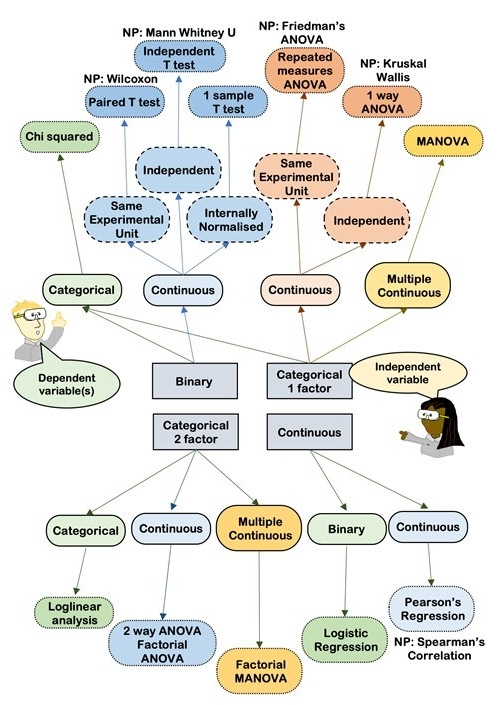

https://lantsandlaminins.com/statistics-test-flow-chart/

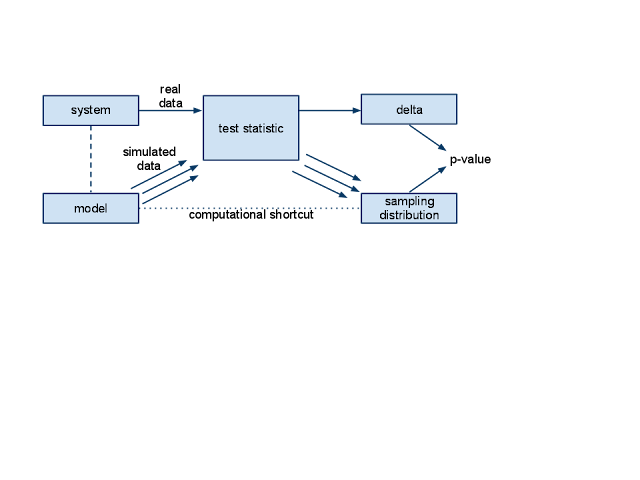

https://allendowney.blogspot.com/2011/05/there-is-only-one-test.html

### “There is only one test”

#### General framework:

1) Compute a test statistic from your data ($\delta^*$) - this measures the size of an effect, like the difference between the means of an experimental group and a control group.

2) Define a null hypothesis - a model built with the assumption that the effect from (1) is not real (e.g., no difference in the means. $H_0: \mu_A = \mu_B$). In other words, a world where $\delta$ is null (basically, zero). This model should generate random *datasets* (yes, many).

3) Compute a test statistic ($\delta$) for each dataset generated under the null hypothesis, computed the same way as it was for your data.

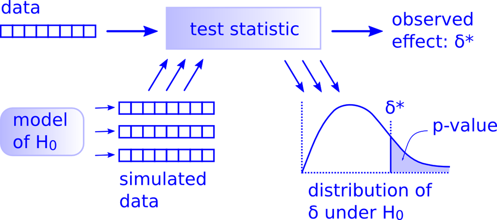

### Implementing the One Test

#### Test statistic

First we need to have data to calculate an observed test statistic. Let’s do what we do and simulate a case where we know the answer.

Let’s say we’re interested in testing the mean ATP synthesis (mg per g biomass per h) of fungi in a control group living on a hay substrate and an experimental group living on hay with acetate added.

```r
library(tidyverse)
library(infer)
```

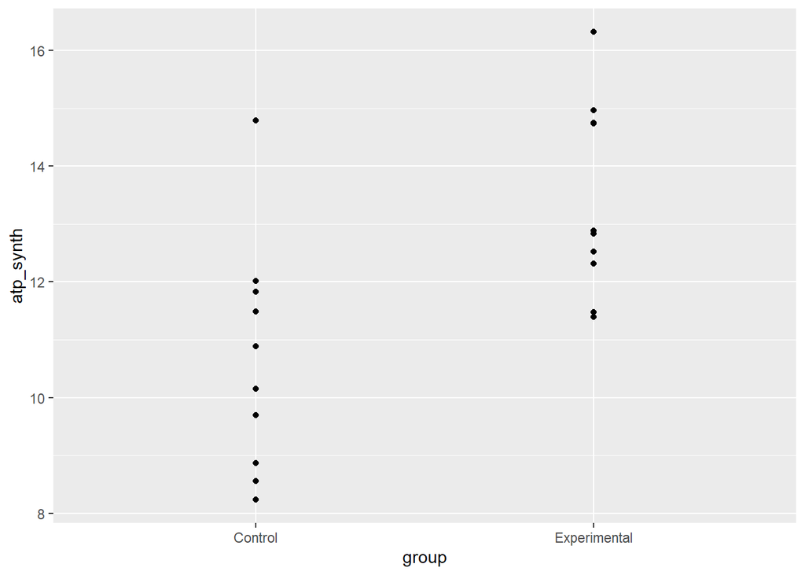

```r
set.seed(90)
n <- 10
atp_df <- tibble(group = c(rep("Control", n), rep("Experimental", n)))|>
  mutate(atp_synth = ifelse(group == "Control",
                            rnorm(n, mean = 10, sd = 2),
                            rnorm(n, mean = 13, sd = 2)))

ggplot(atp_df, aes(x = group, y = atp_synth))+
  geom_point()
```

```r
delta_star <- atp_df|>
  group_by(group)|>
  summarize(atp_synth = mean(atp_synth))|>
  summarize(diff = diff(atp_synth))|>
  pull(diff)
delta_star
```

```
[1] 2.76745
```

What’s the calculated effect ($\delta^*$) of the experiment here if our question is a difference in means?

We can use as our ‘data’ to test $H_0: \mu_A = \mu_B$ (or alternately, $H_A: \mu_A \neq \mu_B$).

### Creating a null world

How do we create a model where our null hypothesis is true?

Remember bootstrapping? Instead of randomly sampling with replacement, let’s randomly existing assign labels to our values. So we’re *reshuffling* our data to simulate how these values could be generated by random chance. This is called **permutation**: changing the order of a set of values.

Here, `sample()` is used with the default argument `replace = FALSE`.

```r
set.seed(90)
atp_df
```

```
# A tibble: 20 × 2
   group        atp_synth
   <chr>            <dbl>
 1 Control          10.2
 2 Control           9.70
 3 Control           8.23
 4 Control           8.56
 5 Control          11.5
 6 Control          10.9
 7 Control          12.0
 8 Control          11.8
 9 Control           8.87
10 Control          14.8
11 Experimental     11.4
12 Experimental     12.8
13 Experimental     14.7
14 Experimental     16.3
15 Experimental     12.5
16 Experimental     12.9
17 Experimental     12.3
18 Experimental     14.7
19 Experimental     15.0
20 Experimental     11.5
```

```r
atp_permdf1 <- atp_df|>
  mutate(group = sample(group))

atp_permdf1
```

```
# A tibble: 20 × 2
   group        atp_synth
   <chr>            <dbl>
 1 Experimental     10.2
 2 Control           9.70
 3 Experimental      8.23
 4 Experimental      8.56
 5 Control          11.5
 6 Control          10.9
 7 Experimental     12.0
 8 Experimental     11.8
 9 Experimental      8.87
10 Control          14.8
11 Control          11.4
12 Control          12.8
13 Experimental     14.7
14 Experimental     16.3
15 Control          12.5
16 Experimental     12.9
17 Control          12.3
18 Control          14.7
19 Control          15.0
20 Experimental     11.5
```

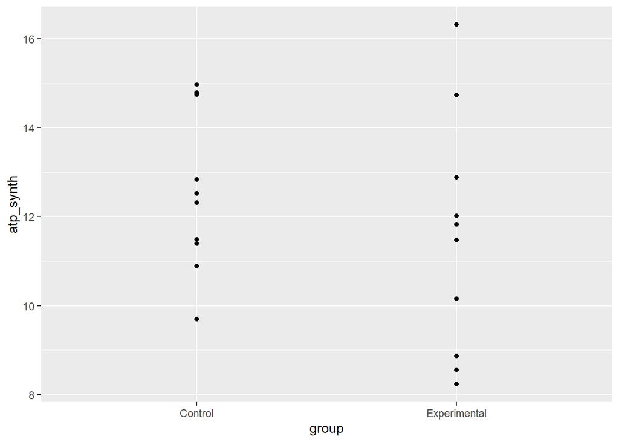

```r
ggplot(atp_permdf1, aes(x = group, y = atp_synth))+
  geom_point()
```

So the values of `atp_synth` stay the same, but the group labels are randomized. *On average*, this means that the association/correlation between group and atp_synth is broken. By the way, this is really what randomization in experimentation is doing - randomly assigning treatments to individuals/units *on average* breaks associations that may influence the effect of the treatment on the outcome.  
Now we can calculate a test statistic ($\delta$) for this permutation.

```r
atp_permdf1|>
  group_by(group)|>
  summarize(atp_synth = mean(atp_synth))|>
  summarize(delta = diff(atp_synth))|>
  pull(delta)
```

```
[1] -1.055138
```

Of course this is different than $\delta^*$, we need to do this many times to develop a distribution of possibilities. I find base R’s `replicate()` to be a little easier to understand here than purrr package use of `map_*` functions here.

Doing 9999 permutations is pretty standard, but it might take a minute.

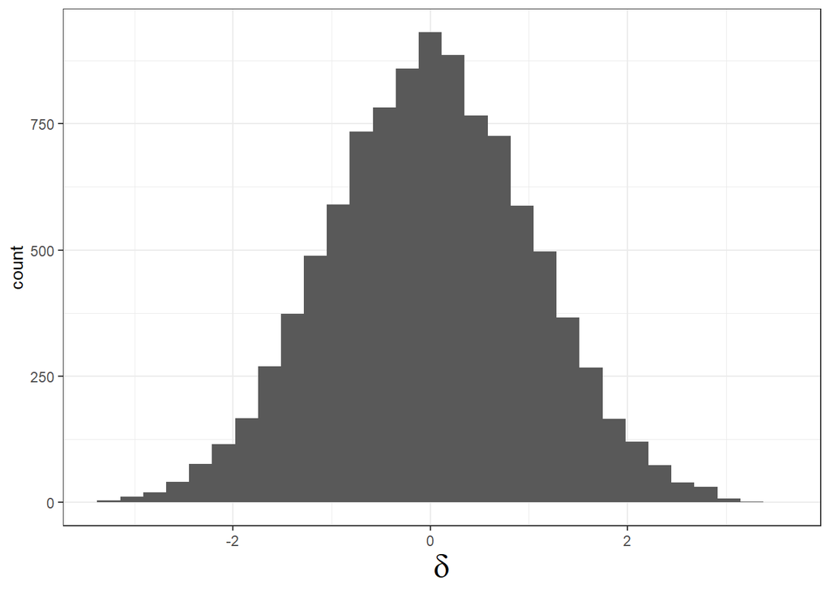

```r
set.seed(3)
perms <- 9999
atp_permdf <- replicate(perms,
                        {
  atp_df|>
  mutate(group = sample(group))|>
  group_by(group)|>
  summarize(atp_synth = mean(atp_synth))|>
  summarize(delta = diff(atp_synth))|>
  pull(delta)

 }
)|>
  as_tibble()|>rename(ts_delta = "value")

ggplot(atp_permdf, aes(x = ts_delta))+
  geom_histogram()+
  xlab(expression(delta))+
  theme_bw()+theme(axis.title.x = element_text(size = 20, face = "bold"))
```

Now let’s compare our null worlds with our observed data.

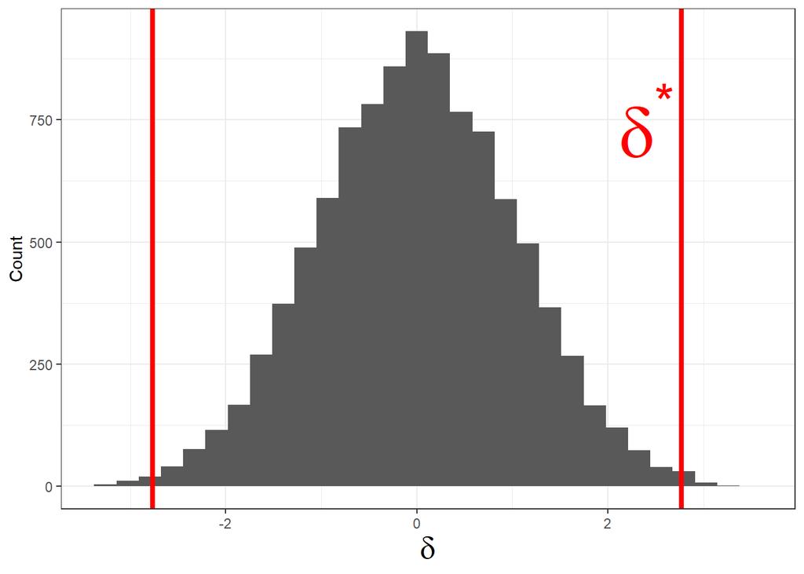

```r
ggplot()+
  geom_histogram(data = atp_permdf, aes(x = ts_delta))+
  geom_vline(aes(xintercept = c(-delta_star,delta_star)), color = "red", size = 1.5)+
  geom_text(aes(x = 0.87*delta_star, y = 750), label = expression(delta^"*"), size = 16, color = "red")+
  xlab(expression(delta))+ylab("Count")+
  theme_bw()+theme(axis.title.x = element_text(size = 20, face = "bold"))
```

### Calculate a P-value

```r
blah <- atp_permdf|>
  mutate(delta_le_deltastar = ifelse(abs(ts_delta) >= abs(delta_star), TRUE, FALSE))|>
  group_by(delta_le_deltastar)|>
  summarize(count = n(), prop = count/perms)
```

So here P = 0.003, which is less than 0.05. Here we would reject the null hypothesis and say there is a ‘significant’ difference in the group means.

In a world where delta is 0, there’s a 0.3% chance of seeing our observed test statistic or something more extreme.

#### Quick note on decision making and error rates

$\alpha = 0.05$ implies we’re using a hypothesis testing procedure that in the long run would *incorrectly* reject $H_0$ 5% of the time.

*Type I errors* - False positives: “Significant difference!” but reality is there is not one (i.e., incorrectly rejecting $H_0$).

*Type II errors* - False negatives: “Ain’t no difference!” but reality is there is one.

Does our chosen alpha reflect a trade-off in Type I and Type II errors?

*S values* - log2(P): S for “Surprise” Brings intuition to Pvalues and can be interpreted as ~number of heads in a row.

### An easier way with the `{infer}` package

I used `replicate()` above and `infer::rep_sample_n()` and `rsample::bootstraps()` in previous lectures to make the process a little more bare bones, but `{infer}` is meant to streamline this process. Let’s try the steps again with the `{infer}` workflow.

#### Calculate the test statistic

First let’s generate an observed test statistic. `specify` works a little like `lm()` in that it expects a formula like `Response ~ Predictor`. Then we can calculate $\delta^*$ as the difference in means using `calculate()` by specifying the statistic and optionally ensuring the order of the calculation of that statistic is what we want in this case the Experimental - Control.

```r
delta_infer <- atp_df|>
  specify(atp_synth ~ group)|>
  calculate(stat = "diff in means", order = c("Experimental","Control"))
```

Exact same value: 2.7674503.

#### Generate a null world

This manages to go a lot faster than my replicate version likely due to some optimization in the way the code is written.

```r
set.seed(3)
shuffled_deltas <- atp_df|>
  specify(atp_synth ~ group)|>
  hypothesize(null = "independence")|>
  generate(reps = 9999, type = "permute")|>
  calculate(stat = "diff in means", order = c("Experimental","Control"))
```

#### Compare the observed statistic with the null world

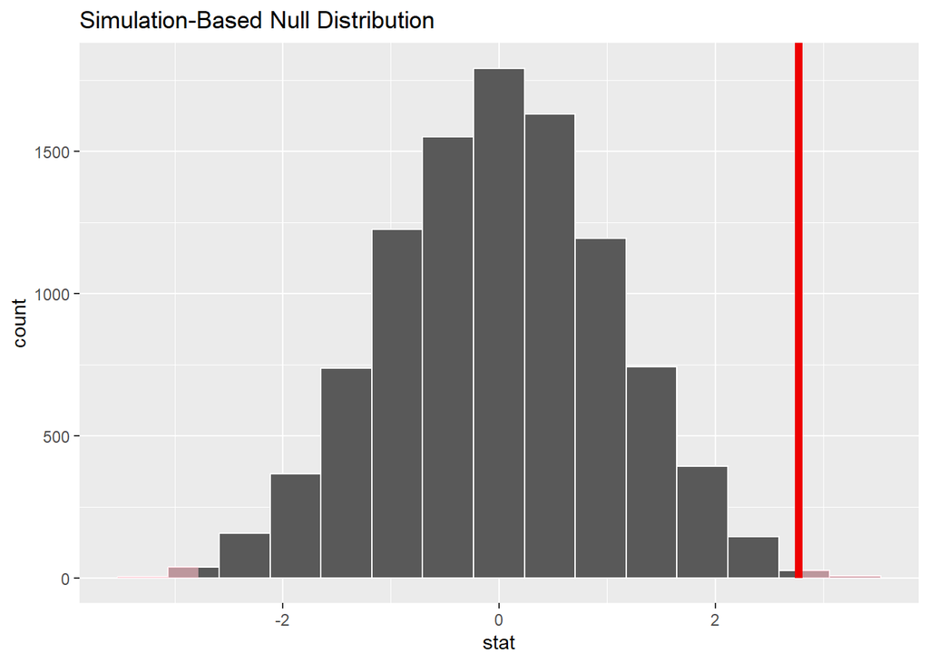

```r
shuffled_deltas|>
  visualize()+
  shade_p_value(obs_stat = delta_infer, direction = "two sided")
```

#### Calculate a P-value

```r
shuffled_deltas |>
  get_p_value(obs_stat = delta_infer, direction = "two sided")
```

```
# A tibble: 1 × 1
  p_value
    <dbl>
1 0.00300
```

How do P values compare with confidence intervals in terms of using their cutoffs to make decisions about significance?

## Named tests and linear models

Next time.

# Discussion

We’re coming to the end of the class materials - here’s what’s planned:

Discussion of named hypothesis tests and linear models (t-tests, ANOVA, chi-square, etc.). Literature presentations on, broadly, poor research practices like P-hacking. A priori power analysis and design.

What kind of statistical, data science, or open science concepts do you want to see?

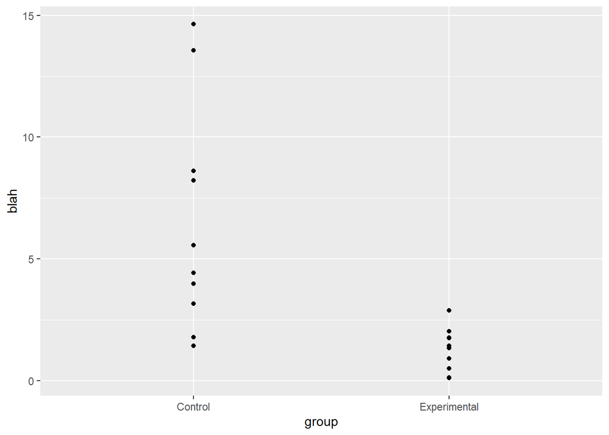

```r
set.seed(90)
n <- 10
blah_df <- tibble(group = c(rep("Control", n), rep("Experimental", n)))|>
  mutate(blah = ifelse(group == "Control",
                            rgamma(n, 1, 0.1),
                            rgamma(n, 1,1)))

ggplot(blah_df, aes(x = group, y = blah))+
  geom_point()#+scale_y_log10()
```

```r
blah_star <- blah_df|>
  group_by(group)|>
  summarize(blah = mean(blah))|>
  summarize(diff = diff(blah))|>
  pull(diff)
blah_star
```

```
[1] -5.255424
```

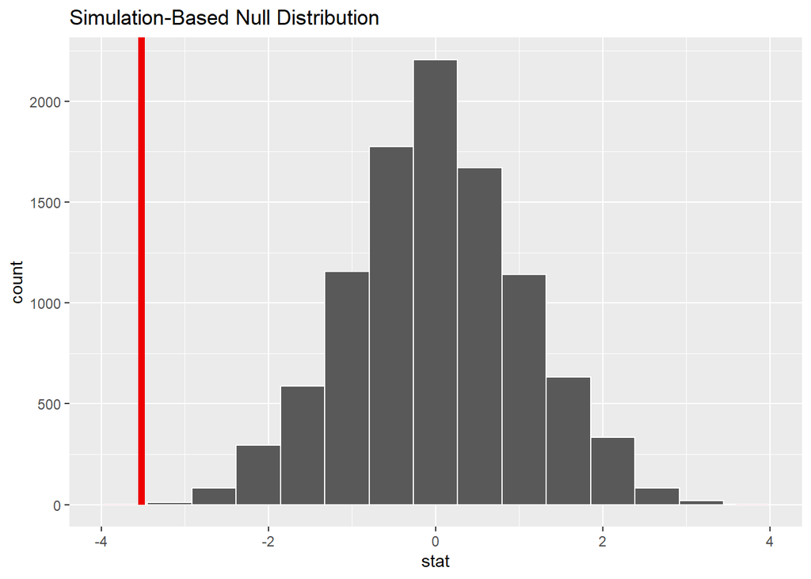

```r
blah_infer <- blah_df|>
  specify(blah ~ group)|>
  calculate(stat = "t", order = c("Experimental","Control"))

shuffled_blah <- blah_df|>
  specify(blah ~ group)|>
  hypothesize(null = "independence")|>
  generate(reps = 9999, type = "permute")|>
  calculate(stat = "t", order = c("Experimental","Control"))

shuffled_blah|>
  visualize()+
  shade_p_value(obs_stat = blah_infer, direction = "both")
```

```r
shuffled_blah|>
  get_p_value(obs_stat = blah_infer, direction = "both")
```

```
# A tibble: 1 × 1
   p_value
     <dbl>
1 0.000200
```